# visualisation_robis

# Visualiser les données OBIS

#### Introduction au package {ggplot2}

Pour faire des cartes statiques dans R, nous utiliserons le package {ggplot2}. Allez chercher des données d occurrence de poisson lune de Ramsay dans OBIS:

```r
#Liste des packages requis. Ici je les ai mis en commentaire car je les ai déjà installés
#install.packages("devtools")
#library(devtools)
#install_github("iobis/robis")
#install.packages("ggplot2")
#install.packages("dplyr")
#install.packages("leaflet")
#install.packages("lubridate")
```

```r
library(udunits2)#pas obligatoire suivant votre installation
library(robis)
molram <- occurrence("Mola ramsayi")
```

```
## Retrieved 81 records of approximately 81 (100%)
```

Nous allons créer un diagramme de dispersion (nuage de point) en utilisant les coordonnées des occurences téléchargées. 1-Initialisez une base de travail vide avec `ggplot()` 2-Utilisez `geom_point()` pour y projeter le nuage de point. `aes()` associe les esthétiques que l on veut utiliser à une variable à représenter (notez que les coordonnées x et y sont aussi considérées comme des esthétiques). Ici la longitude en abscisse et la latitude en ordonnée proviennent de la table molram.

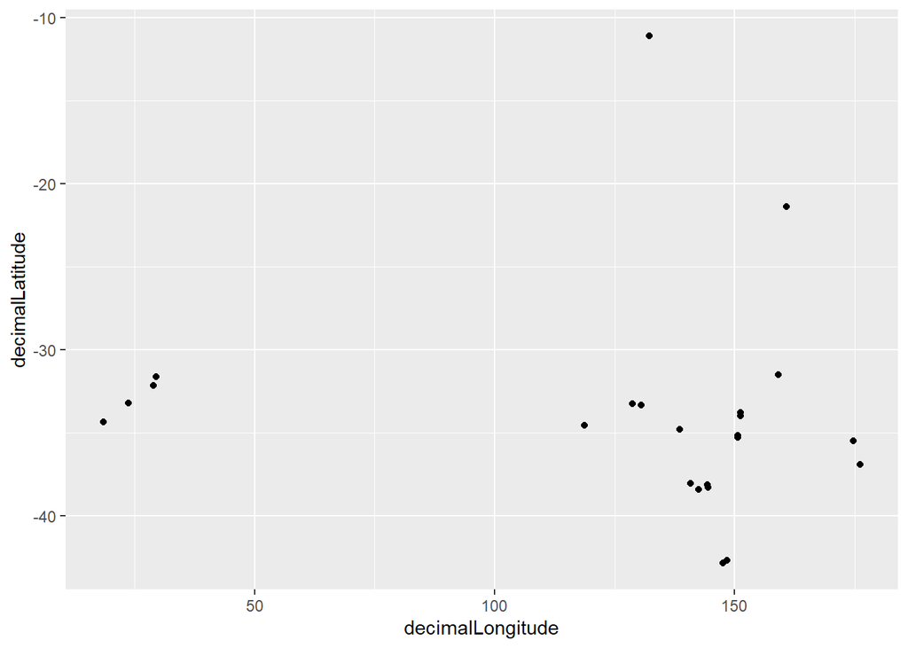

```r
library(ggplot2)
ggplot() + geom_point(data = molram, aes(x = decimalLongitude, y = decimalLatitude))
```

On peut désormais ajouter un polygone du monde à notre carte. `map_data()` permet de charger des cartes de pays, continents ou du monde entier (attention, il faut aussi charger le package {maps}). Comme le polygone et les points sont projetés sur la même base de travail, il faut utiliser `coord_fixed()` pour s assurer que les axes ont la même échelle. N hésitez pas à adapter les valeurs à entrer dans cette fonction pour tenir compte de la latitude de votre travail (équateur, pôles …):

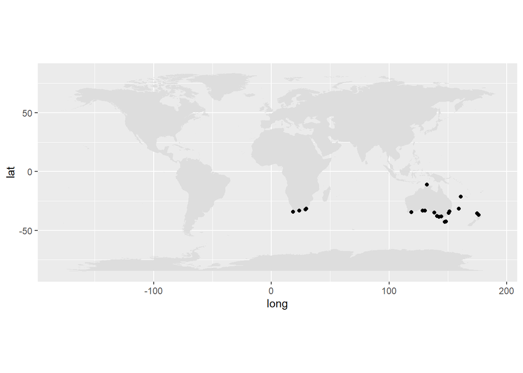

```r
library(maps)
world <- map_data("world")

ggplot() +
 geom_polygon(data = world, aes(x = long, y = lat, group = group), fill = "#dddddd") +
 geom_point(data = molram, aes(x = decimalLongitude, y = decimalLatitude))+
 coord_fixed(1)
```

On peut agrandir la zone qui nous intéresse avec `coord_fixed`:

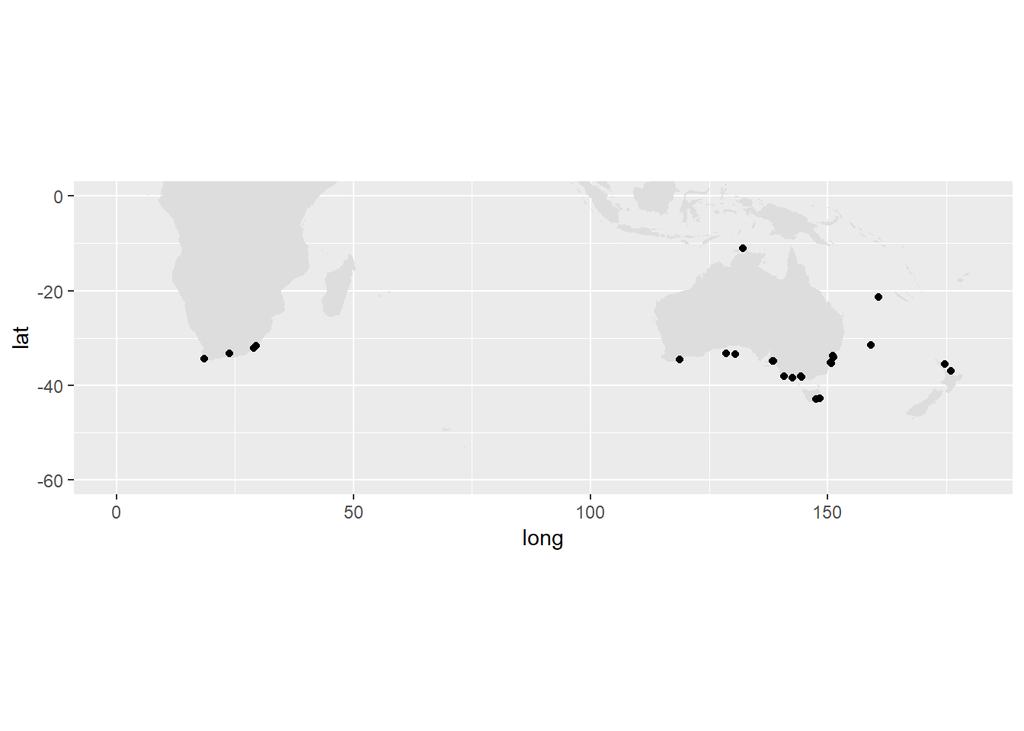

```r
ggplot() +
 geom_polygon(data = world, aes(x = long, y = lat, group = group), fill = "#dddddd") +
 geom_point(data = molram, aes(x = decimalLongitude, y = decimalLatitude)) +
 coord_fixed(1, xlim = c(0, 180), ylim = c(-60, 0))
```

Il y a plusieurs façon de personnaliser les échelles de couleur dans ggplot (p. ex pour les daltoniens), voir `scale_color_brewer()`:

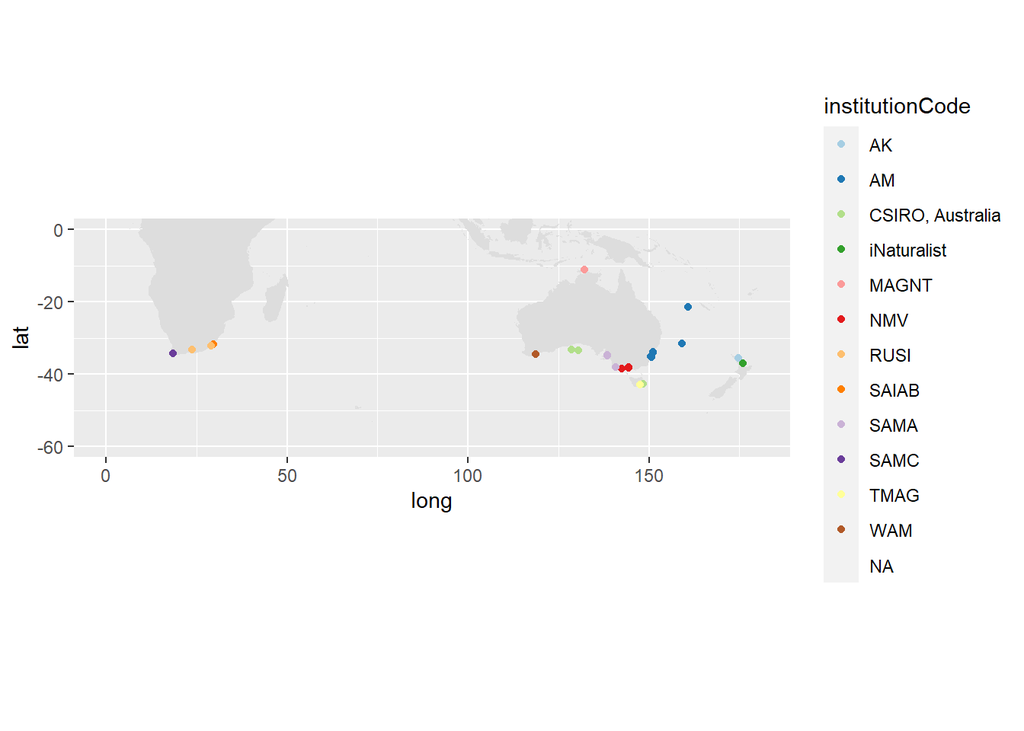

```r
ggplot() +
 geom_polygon(data = world, aes(x = long, y = lat, group = group), fill = "#dddddd") +
 geom_point(data = molram, aes(x = decimalLongitude, y = decimalLatitude, color = institutionCode)) +
 coord_fixed(1, xlim = c(0, 180), ylim = c(-60, 0)) +
 scale_color_brewer(palette = "Paired")
```

`geom_bar()` peut être utilisée pour créer un graphique. Pour essayer, allons d’ abord chercher un peu de données depuis OBIS et créons un simple diagramme en bâton:

```r
dor <- occurrence("Doridoidea")
```

```
## Retrieved 3686 records of approximately 3686 (100%)
```

```r
#observons le nom des colonnes
names(dor)
```

```
##   [1] "country"                       "date_year"
##   [3] "scientificNameID"              "year"
##   [5] "scientificName"                "superfamilyid"
##   [7] "dropped"                       "fieldNumber"
##   [9] "aphiaID"                       "decimalLatitude"
##  [11] "subclassid"                    "phylumid"
##  [13] "familyid"                      "catalogNumber"
##  [15] "occurrenceStatus"              "basisOfRecord"
##  [17] "subterclassid"                 "modified"
##  [19] "maximumDepthInMeters"          "id"
##  [21] "day"                           "order"
##  [23] "recordNumber"                  "infraorderid"
##  [25] "dataset_id"                    "locality"
##  [27] "decimalLongitude"              "collectionCode"
##  [29] "date_end"                      "speciesid"
```

[output cut: 62 more lines]

```r
#avant de faire un graphique avec des dates, toujours verifier comment R interprète ces valeurs
class(dor$year)
```

```
## [1] "character"
```

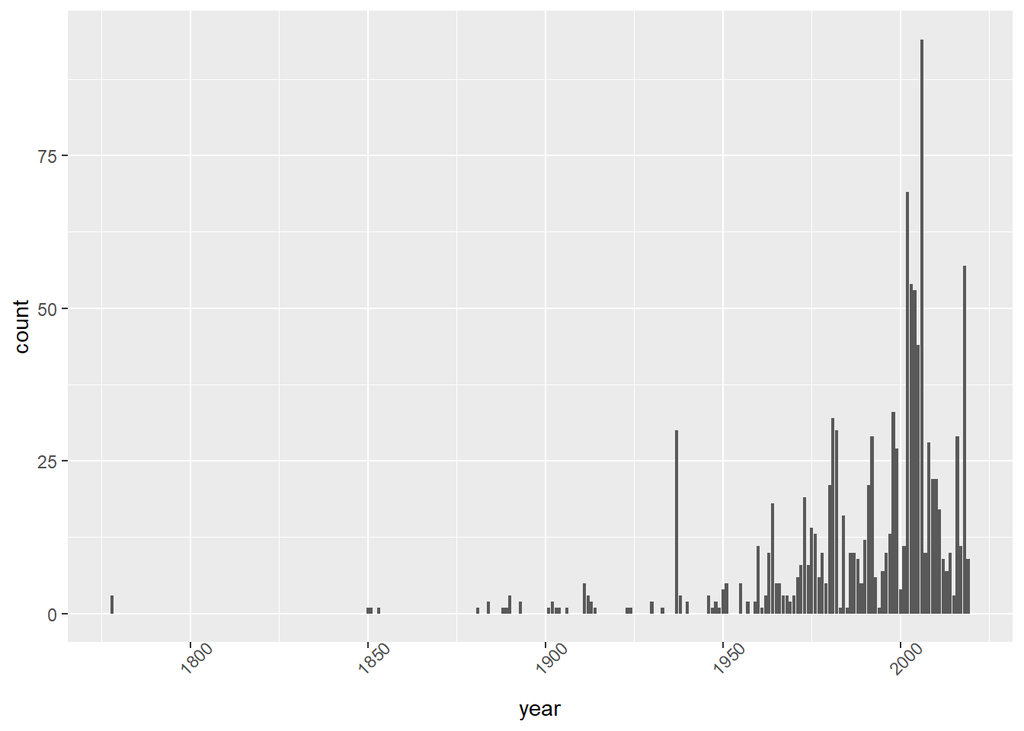

```r
#La réponse étant "character", nous avons besoin de faire comprendre à R que ce sont des dates et non du texte simple, il saura ainsi mieux gérer les graphiques et les NAs
#Il existe différents package pour gérer les dates tels que lubridate
library(lubridate)
annee<-year(as.Date(dor$year,format ="%Y"))
dor$year<-annee

ggplot() +
 geom_bar(data = dor,stat='count', aes(x = year)) +
 theme(axis.text.x = element_text(angle=45))
```

On peut vouloir regrouper les données par classes de 10 ans en créant une nouvelle colonne en utilisant `mutate()` de {dplyr}. Un peu de calcul plus tard vous obtenez vos classes et votre graphique

```r
library(dplyr)
```

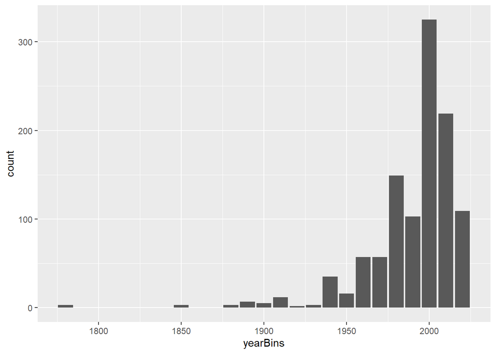

```r
# ici on utilise l opérateur pip %>% pour imbriquer plusieurs actions à la suite dans une même ligne (plus cours que le précédent chunk)
#étape 1 : transformer les années en chiffre (souvenez vous, R les considérait en caractère).`as.integer`
#étape 2 : arrondir ces chiffres à la décennie (2005 devient 2000, 2018 devient 2020). `round`
#étape 3 : ajouterla colonne yearBins. `mutate`
binned_dor <- dor %>% mutate(yearBins=round(as.integer(year),digits=-1) )


ggplot() +
 geom_bar(data = binned_dor,stat='count', aes(x = yearBins))
```

En définissant le paramètre fill= à l esthétique (`aes()`), on peut colorer les bâtons en fonction de la famille et en jouant sur xlim() on peut zoomer un peu:

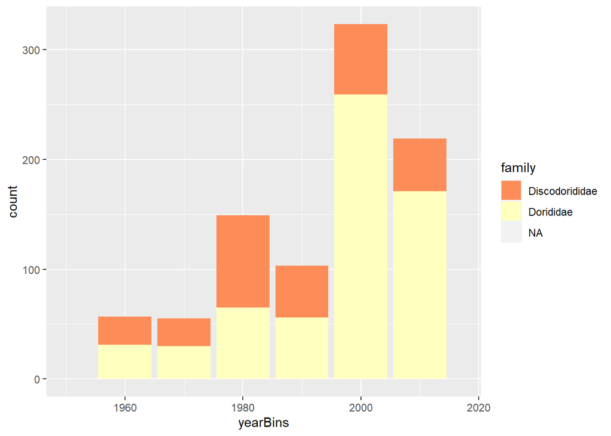

```r
ggplot() +
 geom_histogram(data = binned_dor, stat="count", aes(x = yearBins, fill = family)) +
 scale_fill_brewer(palette = "Spectral") +
 xlim(c(1950, 2017))
```

Passons à une autre fonctionnalité. Vous pouvez, en utilisant `facet_grid()`, séparer votre diagramme en fonction d un ou plusieurs facteurs:

```r
lag <- occurrence("Lagis")
```

```
## Retrieved 5000 records of approximately 27309 (18%) Retrieved 10000 records of
## approximately 27309 (36%) Retrieved 15000 records of approximately 27309 (54%)
## Retrieved 20000 records of approximately 27309 (73%) Retrieved 25000 records of
## approximately 27309 (91%) Retrieved 27309 records of approximately 27309 (100%)
```

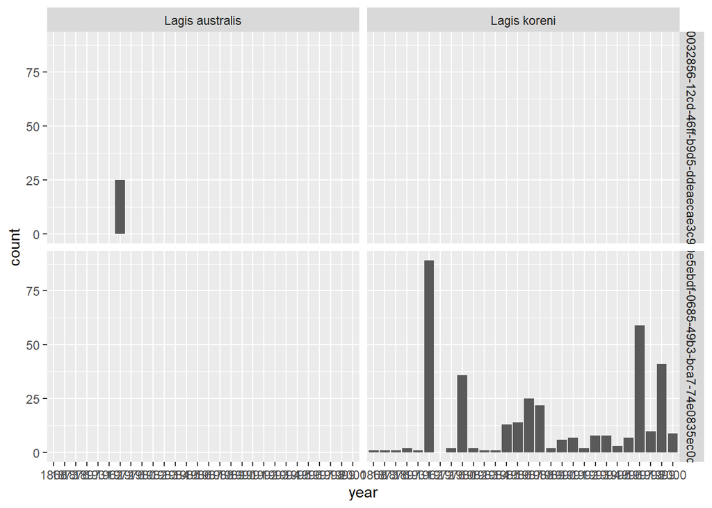

```r
lag_2 <- lag %>% filter(dataset_id %in% c("00032856-12cd-46ff-b9d5-ddeaecae3c95", "f0e5ebdf-0685-49b3-bca7-74e0835ec0dc"))

ggplot() +
 geom_histogram(data = lag_2,stat='count',  aes(x = year), binwidth = 2) +
 facet_grid(dataset_id~ species)
```

# {leaflet} ou les joies des cartes intéractives

Le package {leaflet} englobe la librairie populaire Leaflet JavaScript pour les cartes intéractives. N oubliez pas d installer le package:

##### Une carte simple

Initialisez une carte avec `leaflet()` et ajoutez le fond de carte par défaut OpenStreetMap avec `addTiles()`. Pour changer le fond de carte, choisissez un fournisseur de tuile (p. ex: https://server.arcgisonline.com/arcgis/rest/services) et entrez l URL dans `addTiles()` :

```r
library(leaflet)

leaflet() %>% addTiles("https://server.arcgisonline.com/ArcGIS/rest/services/Ocean_Basemap/MapServer/tile/{z}/{y}/{x}")
```

[interactive chart not shown]

Allons maintenant chercher des données avec {robis} et ajoutons des marqueurs correspondants aux centroides avec la fonction `addCircleMarkers()`. Cette fonction accepte des longitudes et latitudes ainsi que certains paramètres stylistiques:

```r
abrseg <- occurrence("Abra segmentum")
```

```
## Retrieved 757 records of approximately 757 (100%)
```

```r
popup <- paste0(abrseg$datasetName, "<br/>", abrseg$locality, "<br/>",abrseg$catalogNumber,"<br/><a href=\"https://obis.org/dataset/", abrseg$dataset_id, "\">OBIS dataset page</a>")


leaflet() %>%
  addTiles("https://cartodb-basemaps-{s}.global.ssl.fastly.net/light_all/{z}/{x}/{y}.png") %>%
  addCircleMarkers(popup = popup,lat = abrseg$decimalLatitude, lng = abrseg$decimalLongitude, radius = 3.5, weight = 0, fillOpacity = 1, fillColor = "#cc3300")
```

[interactive chart not shown]

##### Plusieurs espèces

Dans l exemple ci dessous, les données sont récupérées et visualisées pour deux espèces de morue.

```r
pac <- occurrence("Gadus macrocephalus", startdate = '1993-01-01',enddate= '1995-01-01')
```

```
## Retrieved 3159 records of approximately 3159 (100%)
```

```r
atl <- occurrence("Gadus morhua", startdate = '1993-01-01',enddate= '1995-01-01')
```

```
## Retrieved 5000 records of approximately 71467 (6%) Retrieved 10000 records of
## approximately 71467 (13%) Retrieved 15000 records of approximately 71467 (20%)
## Retrieved 20000 records of approximately 71467 (27%) Retrieved 25000 records of
## approximately 71467 (34%) Retrieved 30000 records of approximately 71467 (41%)
## Retrieved 35000 records of approximately 71467 (48%) Retrieved 40000 records of
## approximately 71467 (55%) Retrieved 45000 records of approximately 71467 (62%)
## Retrieved 50000 records of approximately 71467 (69%) Retrieved 55000 records of
## approximately 71467 (76%) Retrieved 60000 records of approximately 71467 (83%)
## Retrieved 65000 records of approximately 71467 (90%) Retrieved 70000 records of
## approximately 71467 (97%) Retrieved 71467 records of approximately 71467 (100%)
```

```r
leaflet() %>%
  addProviderTiles("CartoDB.Positron") %>%
  addCircleMarkers(lat = pac$decimalLatitude, lng = pac$decimalLongitude, radius = 3.5, weight = 0, fillOpacity = 1, fillColor = "#ff0066") %>%
  addCircleMarkers(lat = atl$decimalLatitude, lng = atl$decimalLongitude, radius = 3.5, weight = 0, fillOpacity = 1, fillColor = "#0099cc")
```

[interactive chart not shown]